# Lab 4

# Data Me Pls

### James, Anna, Chris, Amanda

## Group Questions

1. Mothers who smoke have increased rates of premature delivery (before 270 days).
2. The newborns of mothers who smoke have smaller birth weights at every gestational age (number of days into pregnancy when child is born).

### Why it Matters

The United States is among the most developed countries in the world; however, they report extremely high levels of misscariage and premature births compared to other developed nations. This study serves as a probe into some potential explanations as to why this is. Although there are many potential causes for pregnancy complications, one which has concrete foundations for studying is the effects of smoking. Establishing a correlation between druge use (smoking in this study) and premature birth rates serves as insight into what steps the general public can look into as a way of reducing the heightened complications of pregnancy. In order to limit the grief families experience, and the health complications that infants endure, a study warning of the dangers of smoking is needed to empirically convey the severity of such actions; the conclusions from this study can be used by the medical community to provide the best care they can for families and babies.

### Conclusions

#### Plots for Conclusion 1

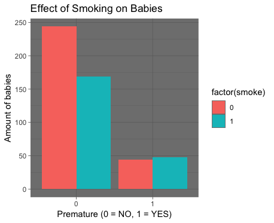

Plot 1

```
ggplot(data=babies)+geom_bar(aes(x=factor(Premature),fill=factor(smoke)),position="dodge")+
labs(x = "Premature (0 = NO, 1 = YES)",y="Amount of babies",title="Effect of Smoking on Babies")+theme_dark()
```

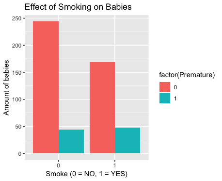

Plot 2

```
ggplot(data=babies)+geom_bar(aes(x=factor(smoke),fill=factor(Premature)),position="dodge")+
labs(x = "Smoke (0 = NO, 1 = YES)",y="Amount of babies",title="Effect of Smoking on Babies")
```

We believe that these two plots provide the best evidence for the Surgeon General’s first assertion. In the first plot, one can clearly see that out of all the premature babies, the majority come from women that said they have smoked. This demonstrates that given that a baby is premature, there is larger probability of the mother being a smoker than nonsmoker. The second plot shows that the proportion of premature babies to nonpremature babies is significantly larger in the case where the mother has smoked. This plot shows that given that the mother smokes, there is a larger probability of the baby being premature compared to if the mother didn’t smoke.

#### Plot for Conclusion 2

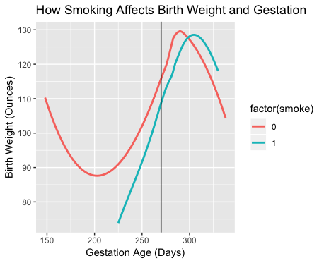

Plot 3

```
ggplot(data=babies)+geom_smooth(aes(x=gestation,y=bwtoz,color=factor(smoke)),se=FALSE)+
geom_vline(xintercept = 270)+labs(x="Gestation Age (Days)",y="Birth Weight (Ounces)",title="How Smoking Affects Birth Weight and Gestation")
```

### Recommendations

As our conclusions stated that smoking mothers seems to be correlated with prematurity and lower birth weights, we reccommend that women do not smoke, especially while they are pregnant, in order to have the healthiest baby possible. We also reccommend that doctors share this information with their patients who are pregnant and strongly discourage them from smoking. Although there are other factors that are correlated with low birth weights and premature gestational ages, the correlation with smoking is strong enough that we reccommend that doctors educate their patients not to smoke while pregnant and that mothers follow this protocol for the health of their babies.

## Preliminary Question

These graphs were done to see the general correlations between two variables. As smoking and most other variables are discrete, we decided to use geom_count() to represent this data best.

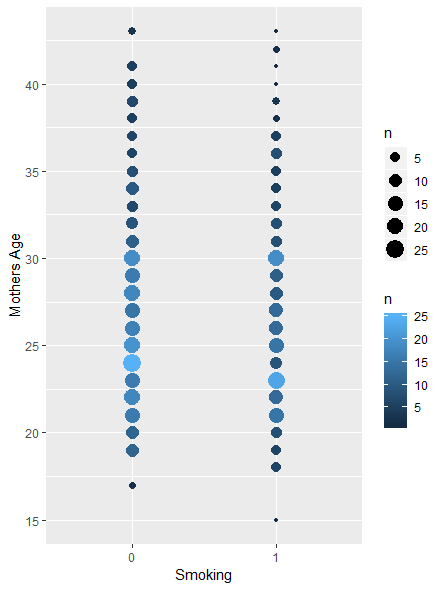

__Smoking and Mother’s Age_

```
ggplot(data=babies,aes(x=as.factor(smoke), y=mage, color=..n..))+ geom_count()+ guides(fill=guide_legend(title="Count"))+
labs(x='Smoking', y='Mothers Age')
```

This graph shows the distribution of the mother’s age when pregnant and whether or not they smoke. The distribution of the two categories (smoking vs. non-smoking) are very different. There is a fairly even distribution of the non-smokers ages around 25, however, there are two large groups of data centered around ages 23 and 30 for those who do smoke. This finding is could be caused by not a large enough sample size or other factors we have not taken into account.

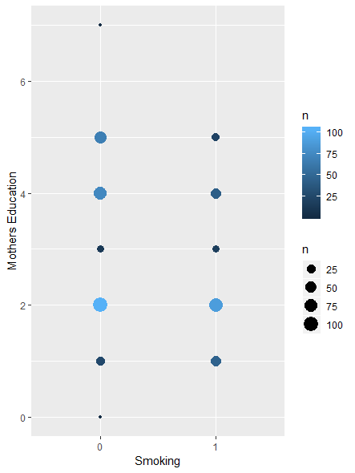

__Smoking and Mother’s Education_

```
ggplot(data=babies,aes(x=as.factor(smoke), y=med, color=..n..))+ geom_count()+ guides(fill=guide_legend(title="Count"))+
labs(x='Smoking', y='Mothers Education')
```

This graph shows the distribution of Mother’s Education (0 being the lowest) and their smoking habits. This graph shows that most of the women who choose to smoke while pregnant have an education level of 2, which represents those who have graduated from high school (as their highest level of schooling). This result is not surprising as the Center for Disease Control reports that adults with less than a high school education are more likely to smoke cigarettes than their peers who have obtained a college degree (https://www.cdc.gov/tobacco/disparities/low-ses/index.htm).

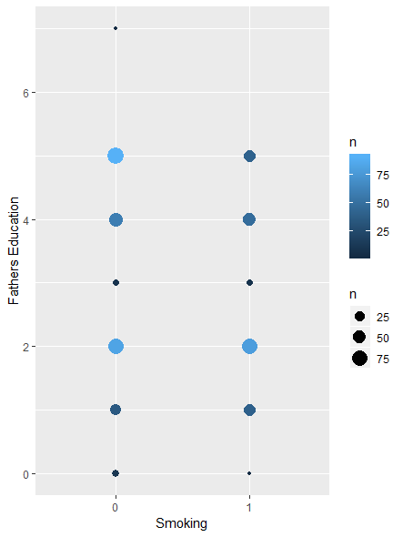

__Smoking and Father’s Education_

```
ggplot(data=babies,aes(x=as.factor(smoke), y=ded, color=..n..))+ geom_count()+ guides(fill=guide_legend(title="Count"))+
labs(x='Smoking', y='Fathers Education')
```

This graph shows the distributions of Father’s Education (0 being the lowest) and the Mother’s Smoking habits. This graph, similar to the one before, also shows that fathers that have an education of 2, which represents those who have graduated from high school (as their highest level of schooling), are the most likely out of all of the education groups to have a wife that smokes. This data may or may not be correlated to the Father’s Smoking habits as well, but this data set did not report the Father’s smoking habits.

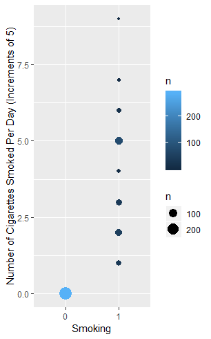

__Smoking and Number of Cigarettes Smoked Per Day_

```
ggplot(data=babies,aes(x=as.factor(smoke), y=number, color=..n..))+ geom_count()+ guides(fill=guide_legend(title="Count"))+
labs(x='Smoking', y='Number of Cigarettes Smoked Per Day (Increments of 5)')
```

This graph shows the relationship between number of cigarettes smoked per day to general smoking habits. The differences between smokers and non-smokers should be very evident as if one does not smoke, the number of cigarettes one smokes per day should be zero.

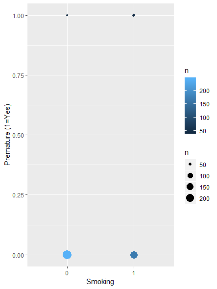

__Smoking and Premature Birth_

```
ggplot(data=babies,aes(x=as.factor(smoke), y=Premature, color=..n..))+ geom_count()+ guides(fill=guide_legend(title="Count"))+
labs(x='Smoking', y='Premature (1=Yes)')
```

This graph shows the amount of babies who were born prematurely were more likely to have had a mother that smoked while pregnant. This data is also very important because this study overall had less participants who smoked while pregnant than who did not. This means that the actual percentage of babies born to mothers who smoke is higher.

A second graph (below) confirms this.

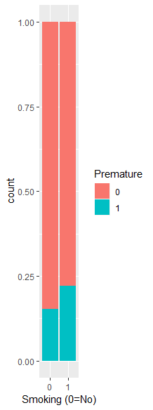

## Individual Questions

### Mother’s ages and premature babys (Chris)

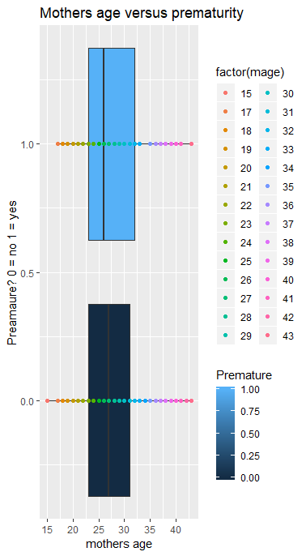

```
ggplot(data = babies, aes(x = Premature , y =mage, group = Premature, fill = Premature)) + geom_boxplot() + coord_flip() + labs(title = "Mothers age versus prematurity" , x = "Preamaure? 0 = no 1 = yes", y = "mothers age") + geom_point(aes(color = factor(mage)))
```

### Premature Births and Parity(Amanda)

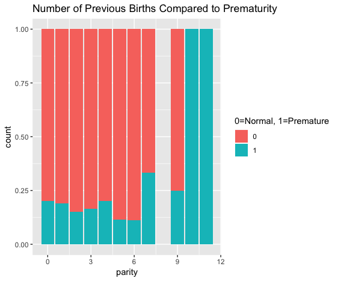

Amanda’s Plot

```
ggplot(data = babies) + geom_bar(mapping = aes(x=parity, fill = as.factor(Premature)), position = "fill")
 + labs(title = "Number of Previous Births Compared to Prematurity") + scale_fill_discrete(name = "0=Normal, 1=Premature")
```

### Mother’s Termination Age and Prematureness (James)

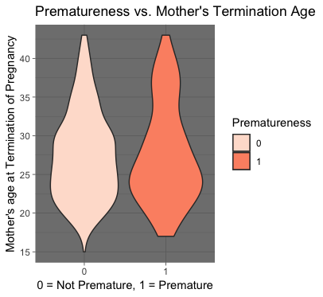

```
ggplot(data=babies)+geom_violin(aes(x=factor(Premature),y=mage,fill=factor(Premature)))+labs(x="0 = Not Premature, 1 = Premature",y="Mother's age at Termination of Pregnancy",title = "Prematureness vs. Mother's Termination Age",fill = "Prematureness")+scale_fill_brewer(palette="Reds")+theme_dark()
```

My goal was to determine if there was any relationship between a baby being premature and the mother’s termination age. By analyzing this plot, it’s clear that there’s not much of a relationship. However, for premature babies, these is an increase of density for mothers that are 35+. This doesn’t answer my question fully, but it does provide some connection between the two variables.

### Smoking and Income (Anna)

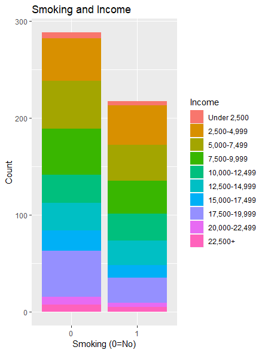

```
ggplot(data=babies)+ geom_bar(mapping=aes(x=as.factor(smoke), fill=as.factor(inc)),position='stack')+ guides(fill=guide_legend(title="Income"))+
scale_fill_discrete(breaks=c('0','1','2','3','4','5','6','7','8','9'),labels=c('Under 2,500','2,500-4,999','5,000-7,499','7,500-9,999','10,000-12,499','12,500-14,999','15,000-17,499','17,500-19,999','20,000-22,499','22,500+'))+
 labs(x= "Smoking (0=No)", title= "Smoking and Income",y= "Count")
```

The relation between Smoking and Income is very important due to the positive relationship between smoking and premature births. A child that is born premature often have a higher chance of medical complications (https://www.mayoclinic.org/diseases-conditions/premature-birth/symptoms-causes/syc-20376730). In this graph, over 50% of the mother’s who smoke have incomes under $12,499. This can be helpful to general providers and those who wish to inform people on the risks of smoking while pregnant.

## A List of Non-Defaults We Used

**Chris**: I used the box plot geom in order to analyze if mother’s age impacts the occurance of prematurity. I used the fill function to change the color of the individual box plots to reflect wheather a baby was premature or not. I changed the labels of the axes and added a title. I also inverted my axes so it was easier to compare the data sets. Finally, I added another geom function to plot the points of ages over the boxplot so it was easier to tell which ages were outliers.

**James**: I used a violin plot. I added labels, changed the title of my legend, and changed the theme of the plot. I also used scale_fill_brewer to change the color of my plot. For the group questions, I helped with generating the plots for the two team questions and interpreting the plots.

**Anna**: I used a bar graph with color being another variable. I also used labs to name specific parts of my plot. I used scale_fill_discrete to also rename parts of my legend. I also used a position funciton inside of my geom_bar function.

**Group**: The Pre Question Plots used geom_cout and geom_bar in similar ways our individual graphs were changed.